# Description du modèle quantique

Nous avons démontré mathématiquement que la fonction d'encodage peut être exprimée comme une série de Fourier avec des portes quantiques.

C'est dans cette partie que nous allons définir toutes les subtilités du modèle pour approximer une fonction.

Mais un seul qubit ne peut pas traiter suffisamment de poids pour approximer n'importe quel type de fonction.

Pour l'heure, on ne peut qu'approximer une fonction trigonométrique élémentaire ($\cos(x)$ ou $\sin(x)$), comme pour la série de Fourier implémentée dans la section précédente, à cause du nombre de poids que l'on peut traiter sur le modèle.

Cette section va être articulée autour de trois implémentations de modèles que l'on va comparer selon deux axes : la performance et la rapidité.

# Définition du modèle quantique avec un qubit

Notre modèle quantique est identique à celui que l'on peut retrouver dans l'article rédigé par son auteur, mais la grande différence est que la gestion des circuits quantiques et de notre simple qubit est manuelle.

Vous pouvez retrouver son implémentation [ici](https://github.com/XanaduAI/expressive_power_of_quantum_models/blob/master/tutorial_expressivity_fourier_series.ipynb). Nous allons en produire deux versions : une version avec notre gestion manuelle des poids et une autre version avec la gestion des poids par PyTorch.

## $S(x)$

$S(x)$, pour notre modèle c'est simplement notre fonction $G(x)$ définie avec l'opérateur $H$, avec son $\sigma$ fixé sur $x$ pour obtenir $R_x$.

On fait le scale sur les inputs $x$ avec $\gamma$ et on l'applique sur le qubit.

Maintenant, présentons notre porte d'encodage $S(x)$ :

```python
from source.quantum_doors import *
from source.quantum_fourier_serie import *

# Définition de S(x)
def S(qubit, x, gamma):
    return quantum_door.RX(qubit, quantum_encoding.x_tilde(x, gamma))
```

Et sa version Torch :

**Nb : Toutes les portes présentées dans les anciens notebooks sont refaites dans une version Torch. Elles sont reconnaissables grâce au préfixe "torch" dans le nom des méthodes.**

```python
def torch_S(qubit, x, gamma):
    return quantum_door.torch_RX(qubit, quantum_encoding.x_tilde(x, gamma))
```

# La boucle de contrôle classique

On va prendre $U(x)$ et faire les rotations avec les différentes portes qui la composent selon les poids sur le qubit choisi pour entraîner le modèle.

Pour rappel :

$$ U(x) = W^{(2)} G(x) W^{(1)} $$

On va faire passer le qubit dans chacune de ses portes et chaque porte $W$ correspond à un triplet d'angles : ($\phi$, $\theta$, $\omega$).

Pour observer le qubit, on va opérer une mesure de [l'observable Pauli-Z](https://qnlab-ustc.github.io/SimQN/tutorials.models.qubit.html). En termes simples, on prend la partie réelle du passage par produit scalaire hermitien du qubit par la matrice Pauli-Z.

**Nb** : On peut utiliser d'autres matrices de sortie, mais il faut savoir que la matrice Pauli-Z reste l'une des plus communes pour réaliser une observation sur l'état des qubits après leur avoir appliqué des opérations.

```python
import numpy as np

# Définition de la boucle de traitement de données quantiques

def serial_quantum_model(qubit, weights, gamma, x=None):

    # On applique les portes sur le qubit avec les poids qui lui sont associés

    for param in weights[:-1]:

        qubit = quantum_encoding.W(qubit, param)

        qubit = S(qubit, x, gamma)

    qubit = quantum_encoding.W(qubit, weights[-1])

    # On effectue une mesure de l'observable Pauli-Z
    return np.real(np.vdot(qubit, quantum_door.Pauli_Z(qubit)))
```

Et sa version Torch :

```python
def torch_serial_quantum_model(qubit, weights, gamma, x=None):

    # On applique les portes sur le qubit avec les poids qui lui sont associés
    for param in weights[:-1]:
        qubit = quantum_encoding.torch_W(qubit, param)
        qubit = torch_S(qubit, x, gamma)

    qubit = quantum_encoding.torch_W(qubit, weights[-1])

    # On effectue une mesure de l'observable Pauli-Z
    expectation = torch.real(torch.vdot(qubit, quantum_door.torch_Pauli_Z(qubit)))
    return expectation
```

# Définition du modèle quantique sur la base de Fourier

Avec la reformulation de $U(x)$ que nous avons faite dans la section précédente, la formule de Fourier nous sert directement de modèle,  
étant équivalente à $U(x)$, qui est un modèle quantique à part entière.

Nb : À la différence du modèle quantique classique à un qubit $U(x)$, notre modèle reposant sur la série de Fourier n'opère pas avec un qubit.  
Il approxime lui-même en se basant sur les angles appliqués aux poids qui lui sont transmis, et sa fonction de coût repose uniquement sur une fonction Adam que nous présenterons après.

En voici une implémntation :

```python
def fourier_model(qubit, weights, gamma, x=None):
    return quatum_fourrier_serie.fourier(x,weights[0],weights[-1],gamma).real
```

# Fonctions élémentaires du modèle

## Fonction de square_loss et cost

Dans un souci expérimental, pour pouvoir retrouver la même valeur que celle obtenue par la personne référente qui a rédigé cet article. Nous nous permettons de copier-coller ses fonctions de cost et square_loss afin de nous comparer d'un point de vue reproductibilité et de mise en condition. Le but de tester notre implémentation et la validité de nos résultats.

La boucle d'entraînement de notre modèle est par ailleurs grandement inspirée de celle implémentée dans son GitHub de référence. Il va de soi que l'utilisation de PennyLane est absente dans notre cas.

Le code de référence peut être retrouver ici : https://github.com/XanaduAI/expressive_power_of_quantum_models/blob/master/tutorial_expressivity_fourier_series.ipynb

```python
def square_loss(targets, predictions):
    loss = 0
    for t, p in zip(targets, predictions):
        loss = loss + (t - p) ** 2
    loss = loss / len(targets)
    return 0.5*loss

def cost(qubit, weights, gamma,x, y, encoding_model):
    predictions = [encoding_model(qubit, weights, gamma, x_i) for x_i in x]
    return square_loss(y, predictions).real
```

## Fonction d'optimisation des poids

Dans le cadre de notre simulation, nous prenons la décision de mettre en place un AdamOptimizer fait "main", afin de le comparer avec une gestion des poids via Torch.

Par conséquent, nous devons coder une fonction pour calibrer les poids ; elle reste classique mais optimisée pour le calibrage des poids matriciels dans notre cas.

Elle ne prend pas en compte la structure quantique.

Nous mettrons un autre modèle basé sur PyTorch par la suite.

Pour l'heure, notre fonction de booste est inspirer de [Adaboost-pennylanne](https://docs.pennylane.ai/en/stable/_modules/pennylane/optimize/adam.html)

Voici la structure du mdèle d'optimisation :

- self.learning_rate : comme son nom l'indique son taux d'apprentissage, la vitesse de mise à jour des poids dans le modèle
- self.beta1 : variable qui sert à lisser l'apprentissage
- self.beta2 : comme beta1, il sert à lisser l'apprentissage
- self.epsilon : nombre de stabilisation numérique
- self.delta : perturbation pour le calcul du gradient
- self.counterTurn : conteur d'itteration pour les mise à jour
- self.averageExponetiel : moyenne exponentielle des gradeitn qui est cumulé sur les itteration
- self.averageExmpentielControlled : moyenne exponenatielle maitriser par le lissage de l'apprentissage

```python
import numpy as np

class AdamOptimizer:

    # Initialisation du modèle avec ses composantes
    def __init__(self, learning_rate=0.01, beta1=0.9, beta2=0.999, eps=1e-8, delta=1e-5):
        self.learning_rate = learning_rate
        self.beta1 = beta1
        self.beta2 = beta2
        self.epsilon = eps
        self.delta = delta
        self.counterTurn = 0
        self.averageExponetiel = None
        self.averageExmpentielControlled = None

    # Calcul des gradients
    def compute_gradient(self, f, w):

        # On initialise le gradient à zéro
        grad = np.zeros_like(w)

        # On calcule les gradients pour chaque poids
        for idx in np.ndindex(w.shape):

            # On détermine les valeurs perturbées pour le poids actuel
            w_plus = np.copy(w)
            w_minus = np.copy(w)
            w_plus[idx] += self.delta
            w_minus[idx] -= self.delta

            f_plus = f(w_plus)
            f_minus = f(w_minus)

            # On calcule le gradient pour le poids concerné
            grad[idx] = (f_plus - f_minus) / (2 * self.delta)

        return grad

    def step(self, f, w):

        # On initialise les moyennes si elles ne sont pas encore définies
        if self.averageExponetiel is None:
            self.averageExponetiel = np.zeros_like(w)
        if self.averageExmpentielControlled is None:
            self.averageExmpentielControlled = np.zeros_like(w)

        # On incrémente le compteur d'itérations
        self.counterTurn += 1

        # On récupère les gradients calculés
        grad = self.compute_gradient(f, w)

        # On calcule la moyenne exponentielle des gradients et celle des carrés des gradients
        self.averageExponetiel = self.beta1 * self.averageExponetiel + (1 - self.beta1) * grad
        self.averageExmpentielControlled = self.beta2 * self.averageExmpentielControlled + (1 - self.beta2) * (grad ** 2)

        # Correction des biais sur les moyennes
        m_hat = self.averageExponetiel / (1 - self.beta1 ** self.counterTurn)
        v_hat = self.averageExmpentielControlled / (1 - self.beta2 ** self.counterTurn)

        # Mise à jour des poids
        w_new = w - self.learning_rate * m_hat / (np.sqrt(v_hat) + self.epsilon)
        return w_new
```

## Fonctions d'approximation des fonctions

La fonction d'approximation n'est pas générique dans ce cas-ci.

Elle va structurer un socle commun pour la mise en place de la comparaison des divers modèles entre celui de l'article, le nôtre et son approximation par série de Fourier.

Les paramètres :

- *function* : la fonction que l'on cherche à approximer
- *gamma* : le coefficient de mise à l'échelle des données
- *steps* : nombre de tours pour l'entraînement
- *encoding_model* : le type de modèle que l'on souhaite faire fonctionner

Dans la méthode, on fixe le *num_layers* à 3 pour les 3 angles ($\phi$, $\theta$, $\omega$) et *batch_size* à 25. Ce sont des paramètres immuables pour la comparaison des modèles dans le contexte de notre expérimentation.

On initialise les poids comme dans l'implémentation de l'article et on va mettre en place une récupération des coûts pour pouvoir les représenter sous forme de graphe.

```python
# Définition de la fonction approximate_function

def approximate_function(function, gamma, steps, encoding_model):

    # On fixe les hyperparamètres du modèle
    x = np.linspace(-6, 6, 70)
    target_y = np.array([function(x_) for x_ in x])

    qubit_fondamental = np.array([1, 0])

    num_layers = 3
    batch_size = 25

    cst = []

    # On initialise l'Adam Optimiseur quantique
    opt = AdamOptimizer(learning_rate=0.3)
    weights = 2 * np.pi * np.random.random(size=(2, num_layers))

    # On effectue la boucle d'entraînement
    for step in range(steps):

        # On initialise les batchs
        batch_index = np.random.randint(0, len(x), batch_size)
        x_batch = x[batch_index]
        y_batch = target_y[batch_index]

        # On régule et stocke les nouveaux poids
        weights = opt.step(lambda w: cost(qubit_fondamental, w, gamma, x_batch, y_batch, encoding_model), weights)

        # On calcule le coût et on le stocke
        c = cost(qubit_fondamental, weights, gamma, x, target_y, encoding_model)
        cst.append(c)
        if (step + 1) % 10 == 0:
            print("Cost at step {:3d}: {:.6f}".format(step + 1, c))

    # On retourne l'historique et les poids du modèle
    return cst, weights
```

# Les modèles basés sur PyTorch

De cette fonction générique, on va construire un nouveau modèle : un pour le modèle quantique à un qubit basé sur la gestion des poids avec PyTorch.

**NB : Nous ne produisons pas de vectorisation dans cette structure pour la gestion des inputs, cela serait simplement inutile, car chaque opération qui modifie le qubit dépend du précédent.**

Voici son implémentation :

```python
import torch
import torch.nn as nn
import torch.optim as optim
import numpy as np

device = torch.device("cuda" if torch.cuda.is_available() else "cpu")

class QuantumApproximate(nn.Module):


    def __init__(self, encoding_model, gamma, num_layers=3):
        super().__init__()

        # On fixe les hyperparamètres du modèle
        self.num_layers = num_layers
        self.weights = nn.Parameter(2 * torch.pi * torch.rand(2, self.num_layers))
        self.gamma = gamma
        self.encoding_model = encoding_model
        self.register_buffer('qubit', torch.tensor([1.0, 0.0], dtype=torch.complex64))


    # Fonction de forward qui prend notre modèle Torch comme référence
    def forward(self, x: torch.Tensor) -> torch.Tensor:
        outputs = []
        for x_i in x:
            state = self.encoding_model(self.qubit, self.weights, self.gamma, x_i)
            outputs.append(torch.real(state))
        encoded = torch.stack(outputs)
        return encoded * self.weights.sum()

    # fonctions de coups inspirer de l'implementation sur github
    # ********
    def square_loss(self, targets, predictions):
        loss = torch.tensor(0.0, dtype=predictions[0].dtype, device=predictions[0].device)
        for t, p in zip(targets, predictions):
            t_tensor = t if torch.is_tensor(t) else torch.tensor(t, dtype=predictions[0].dtype, device=predictions[0].device)
            loss += (t_tensor - p) ** 2
        loss = loss / len(targets)
        return 0.5 * loss.real

    def cost(self, pred_y: torch.Tensor, y: torch.Tensor) -> torch.Tensor:
        return self.square_loss(y, pred_y)
    # ********

    # Fonction d'entraînement
    def fit(self, function, steps: int, lr: float = 0.3, batch_size: int = 25):

        x = np.linspace(-6, 6, 70, dtype=np.float32)
        y = np.array([function(x_) for x_ in x], dtype=np.float32)

    # On fixe l'optimiseur Torch le plus proche de notre modèle de référence
        optimizer = optim.Adagrad(self.parameters(), lr=lr, eps=1e-8)
        cost_history = []

        for step in range(steps):
            indices = np.random.choice(len(x), batch_size, replace=False)
            x_batch = torch.from_numpy(x[indices])
            y_batch = torch.from_numpy(y[indices])

            optimizer.zero_grad()
            preds = self(x_batch)
            loss = self.cost(preds, y_batch) / 2
            loss.backward()
            optimizer.step()

            cost_history.append(loss.item())
            if (step + 1) % 10 == 0:
                print(f"Step {step+1}: Loss = {loss.item():.6f}")

        return cost_history, self.weights


    # Fonction pour charger les poids

    def load_weights(self, weights):

        if isinstance(weights, np.ndarray):
            w = torch.from_numpy(weights).to(self.weights.device).type_as(self.weights)
        elif not torch.is_tensor(weights):
            w = torch.tensor(weights, dtype=self.weights.dtype, device=self.weights.device)
        else:
            w = weights.to(self.weights.device)

        with torch.no_grad():
            self.weights.copy_(w)
```

## Construction de fonctions génériques pour construire et entraîner les modèles

On construit ces méthodes de la manière suivante pour faciliter la présentation, l'implémentation et l'analyse des résultats.

```python
def quantum_spectral_approximation(fonction, gamma, steps, torch = False):
    if(torch):
        model = QuantumApproximate(torch_serial_quantum_model,gamma)
        return model.fit(fonction,steps)
    else:
        return approximate_function(fonction,gamma,steps,serial_quantum_model)

def quantum_variational_fourier_encoding(fonction, gamma, steps, torch = False):
    return approximate_function(fonction,gamma,steps,fourier_model)
```

## La fonction de visualisation des résultats

On va construire la fonction pour afficher la courbe de coût et le rendu de l'approximation de la fonction sinus.

Les paramètres :

- *function* : la fonction que l'on cherche à approximer
- *cst* : l'historique des coûts sorti suite à l'approximation du modèle
- *weight* : les poids à la sortie du modèle
- *gamma* : le coefficient de mise à l'échelle des données
- *steps* : nombre de tours pour l'entraînement
- *encoding_model* : le type de modèle que l'on souhaite faire fonctionner

```python
import matplotlib.pyplot as plt

def show_loss_approximate(function, cst, weights, gamma, encoding_model):

    x = np.linspace(-6, 6, 70)
    target_y = np.array([function(x_) for x_ in x])

    qubit_fondamental = np.array([1, 0])

    plt.figure(figsize=(12, 5))
    plt.subplot(1, 2, 1)
    plt.plot(cst)
    plt.title("Évolution de la Loss")
    plt.xlabel("Itération")
    plt.ylabel("Loss")

    predictions = [encoding_model(qubit_fondamental, weights, gamma, x_i) for x_i in x]
    plt.subplot(1, 2, 2)
    plt.plot(x, target_y, label="f(x)", linewidth=2)
    plt.plot(x, predictions, '--', label="Prédiction", linewidth=2)
    plt.title("Approximation de f(x)")
    plt.xlabel("x")
    plt.ylabel("Valeur")
    plt.legend()

    plt.tight_layout()
    plt.show()
```

Et sa version torch :

```python
def torch_show_loss_approximate(function, cst, weights, gamma, encoding_model):

    x = np.linspace(-6, 6, 70, dtype=np.float32)
    target_y = np.array([function(x_) for x_ in x], dtype=np.float32)

    num_layers = weights.shape[1]

    model = QuantumApproximate(encoding_model, gamma, num_layers=num_layers)
    model.load_weights(weights)

    model.eval()
    x_tensor = torch.from_numpy(x)

    with torch.no_grad():
        predictions = model(x_tensor).detach().cpu().numpy()

    plt.figure(figsize=(12, 5))

    plt.subplot(1, 2, 1)
    plt.plot(cst, label="Loss", linewidth=2)
    plt.title("Évolution de la Loss")
    plt.xlabel("Itération")
    plt.ylabel("Loss")
    plt.legend()

    plt.subplot(1, 2, 2)
    plt.plot(x, target_y, label="f(x)", linewidth=2)
    plt.plot(x, predictions, '--', label="Prédiction", linewidth=2)
    plt.title("Approximation de f(x)")
    plt.xlabel("x")
    plt.ylabel("Valeur")
    plt.legend()

    plt.tight_layout()
    plt.show()
```

Comme pour la fonction d'approximation, on va faire une fonction propre à chacune des deux modèles pour afficher leurs résultats.

```python
def show_loss_approximate_spectral(function, cst,weights, gamma, torch = False):
    if(torch):
        torch_show_loss_approximate(function, cst,weights, gamma,torch_serial_quantum_model)
    else :
        show_loss_approximate(function, cst,weights, gamma,serial_quantum_model)

def show_loss_approximate_fourrier(function, cst,weights, gamma, torch = False):
    show_loss_approximate(function, cst,weights, gamma,fourier_model)
```

# Définition de la fonction à approximer

Nous construisons notre dataset d'entraînement du modèle sur la sortie de la fonction sinus que nous allons essayer d'approximer.

On va l'afficher, montrer les points que l'on va garder pour le dataset afin d'assurer sa reproductibilité d'un point de vue expérimental.

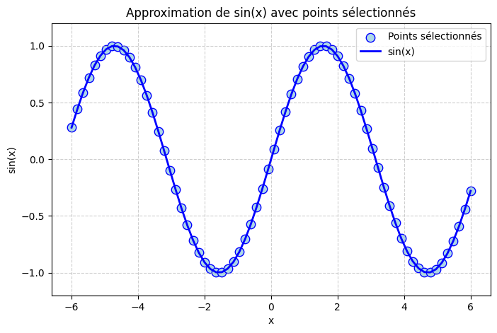

```python
import numpy as np

# La fonction objectif
def fonction(x):
    return np.sin(x)

# Génération des points qui servent d'entraînement pour le modèle
x = np.linspace(-6, 6, 70)
y = np.array([fonction(x_) for x_ in x])

# On affiche la fonction sinus avec les points sélectionnés pour l'entraînement
plt.figure(figsize=(8, 5))
plt.scatter(x, y, facecolors="lightblue", edgecolors="blue", label="Points sélectionnés", s=80)
plt.plot(x, y, label="sin(x)", color="blue", linewidth=2)

plt.title("Approximation de sin(x) avec points sélectionnés")
plt.xlabel("x")
plt.ylabel("sin(x)")
plt.ylim(-1.2, 1.2)
plt.grid(True, linestyle="--", alpha=0.6)
plt.legend()
plt.show()
```

# Approximation des fonctions

### La fonction sinus avec $ \gamma = 1$

$$ f(x) = sin(x) $$

Résultat dans l'article :

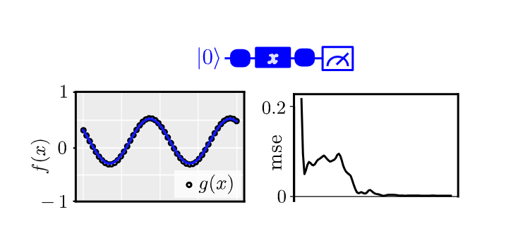

```
Step 10: Loss = 9.671556
Step 20: Loss = 4.760469
Step 30: Loss = 6.788553
Step 40: Loss = 10.465374
Step 50: Loss = 3.101820
Step 60: Loss = 1.869620
Step 70: Loss = 1.955603
Step 80: Loss = 1.726492
Step 90: Loss = 1.317810
Step 100: Loss = 1.091678
Step 110: Loss = 0.792759
Step 120: Loss = 0.405626
Step 130: Loss = 0.347824
Step 140: Loss = 0.188716
Step 150: Loss = 0.111073
Step 160: Loss = 0.093954
Step 170: Loss = 0.064908
Step 180: Loss = 0.052650
Step 190: Loss = 0.059652
Step 200: Loss = 0.038368
Step 210: Loss = 0.045910
Step 220: Loss = 0.042415
Step 230: Loss = 0.040924
Step 240: Loss = 0.039542
Step 250: Loss = 0.046555
Step 260: Loss = 0.035873
Step 270: Loss = 0.040540
Step 280: Loss = 0.034646
Step 290: Loss = 0.038353
Step 300: Loss = 0.046558
Step 310: Loss = 0.036139
Step 320: Loss = 0.035582
Step 330: Loss = 0.045515
Step 340: Loss = 0.043339
Step 350: Loss = 0.042291
Step 360: Loss = 0.040859
Step 370: Loss = 0.044213
Step 380: Loss = 0.043758
Step 390: Loss = 0.031286
Step 400: Loss = 0.047633
```

[output cut: 46 more lines]

```
Step 870: Loss = 0.045586
Step 880: Loss = 0.032586
Step 890: Loss = 0.035755
Step 900: Loss = 0.041913
Step 910: Loss = 0.035363
Step 920: Loss = 0.046462
Step 930: Loss = 0.039305
Step 940: Loss = 0.044216
Step 950: Loss = 0.042019
Step 960: Loss = 0.046929
Step 970: Loss = 0.046664
Step 980: Loss = 0.038168
Step 990: Loss = 0.041061
Step 1000: Loss = 0.036842
Temps d'exécution (torch=True) : 9.81258 secondes
```

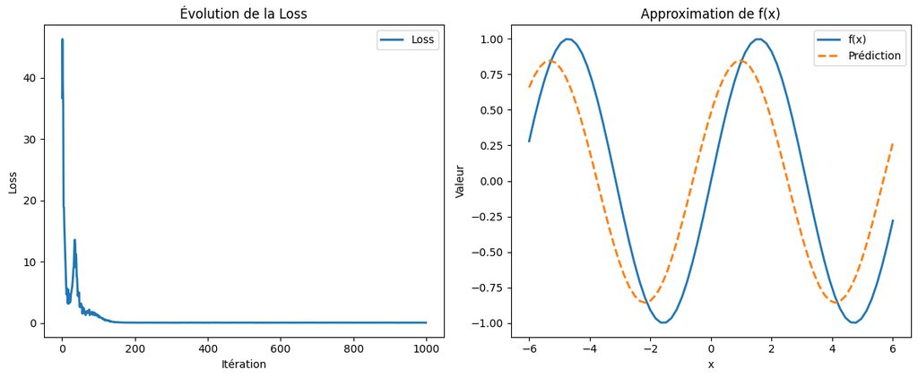

```
Cost at step  10: 0.023829
Cost at step  20: 0.002291
Cost at step  30: 0.001388
Cost at step  40: 0.000218
Cost at step  50: 0.000004
Cost at step  60: 0.000014
Temps d'exécution (torch=False) : 0.67702 secondes
```

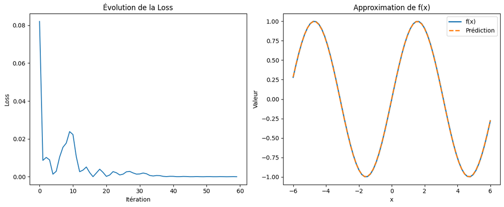

```python
import time

# Hyper-paramètres

gamma = 1

steps = 1000

# Fonction objectif à approximer
def fonction(x):
    return np.sin(x)


# Chronométrage des différents types d'exécution

start_time = time.time()
cst, weights = quantum_spectral_approximation(fonction, gamma, steps, torch=True)
end_time = time.time()
print(f"Temps d'exécution (torch=True) : {end_time - start_time:.5f} secondes")

show_loss_approximate_spectral(fonction, cst, weights, gamma, torch= True)

steps = 60

start_time = time.time()
cst, weights = quantum_spectral_approximation(fonction, gamma, steps)
end_time = time.time()
print(f"Temps d'exécution (torch=False) : {end_time - start_time:.5f} secondes")


# Affichage de la courbe
show_loss_approximate_spectral(fonction, cst, weights, gamma)
```

Maintenant, nous faisons la même opération mais sur la série de Fourier quantique.

On peut souligner la présence d'un facteur 2 devant le paramètre $\tilde{x}$ :

$$ f(x) = c_0 \;+\; 2\,\lvert c_2\rvert\;\cos\!\bigl(2\tilde{x} - \arg(c_2)\bigr) $$ On devra donc diviser par deux notre $\gamma$ pour obtenir le même gamma pour le traitement.

Donc, on a $\gamma = 0.5$.

```
Cost at step  10: 0.038160
Cost at step  20: 0.001365
Cost at step  30: 0.004186
Cost at step  40: 0.000744
Cost at step  50: 0.000431
Cost at step  60: 0.000232
Cost at step  70: 0.000029
Cost at step  80: 0.000012
Cost at step  90: 0.000010
Cost at step 100: 0.000001
Temps d'exécution de show_loss_approximate_spectral : 0.67702 secondes
```

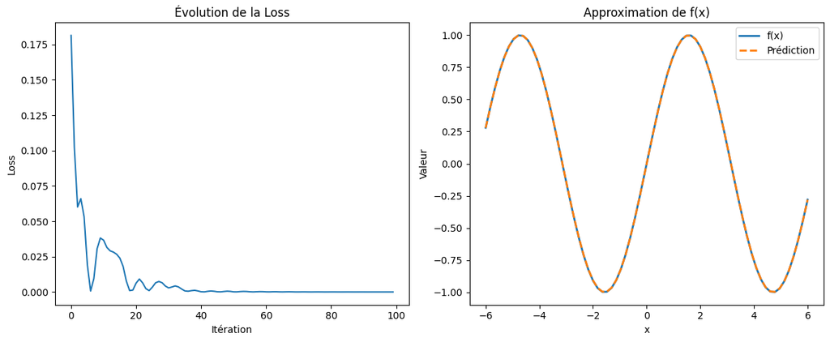

```python
# Hyper-paramètres

gamma = .5

steps = 100

# Fonction objectif à approximer
def fonction(x):
    return np.sin(x)

cst, weights = quantum_variational_fourier_encoding(fonction, gamma, steps)
print(f"Temps d'exécution de show_loss_approximate_spectral : {end_time - start_time:.5f} secondes")


# Affichage de la courbe
show_loss_approximate_fourrier(fonction, cst, weights, gamma)
```

Nous pouvons attester que la série de Fourier tronquée, basée sur des qubits, peut approximer la fonction élémentaire sinusoïdale tout comme les modèles de deep learning quantique.

### La fonction sinus avec $ \gamma = 2$

$$ f(x) = sin(x) $$

Résultat dans l'article :

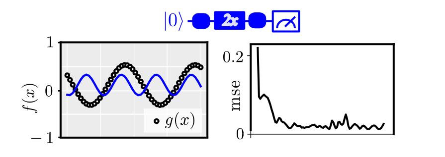

On procède à l'entraînement, comme dans son document de référence, avec $\gamma = 2$ sur le mdèle à un qubit.

```
Step 10: Loss = 7.626418
Step 20: Loss = 6.995486
Step 30: Loss = 3.382908
Step 40: Loss = 2.127098
Step 50: Loss = 0.919323
Step 60: Loss = 0.533485
Step 70: Loss = 0.172633
Step 80: Loss = 0.343849
Step 90: Loss = 0.183181
Step 100: Loss = 0.166008
Temps d'exécution (torch=True) : 0.87119 secondes
```

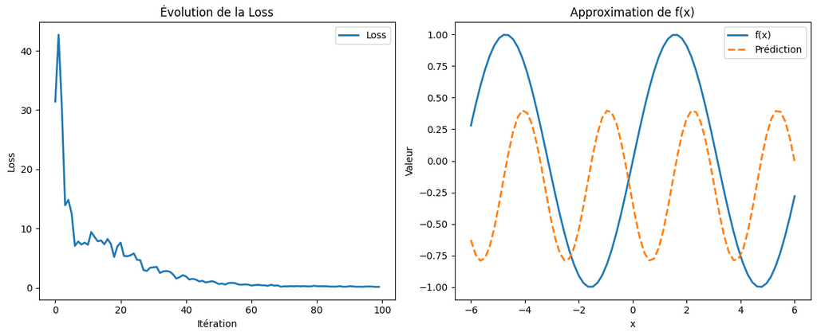

```
Cost at step  10: 0.279994
Cost at step  20: 0.284066
Cost at step  30: 0.272038
Cost at step  40: 0.271274
Cost at step  50: 0.267604
Cost at step  60: 0.280036
Cost at step  70: 0.257978
Cost at step  80: 0.267778
Cost at step  90: 0.268478
Cost at step 100: 0.281865
Temps d'exécution (torch=False) : 1.08532 secondes
```

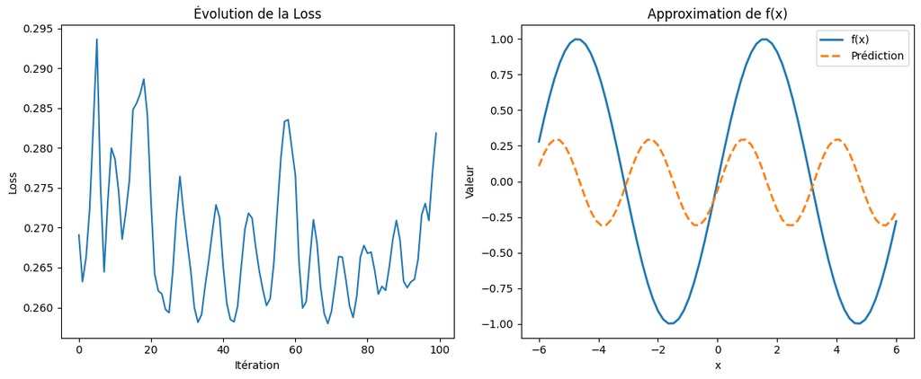

```python
# Hyper-paramètres

gamma = 2

steps = 100

# Fonction objectif à approximer
def fonction(x):
    return np.sin(x)

# Chronométrage des différents types d'exécution
start_time = time.time()
cst, weights = quantum_spectral_approximation(fonction, gamma, steps, torch=True)
end_time = time.time()
print(f"Temps d'exécution (torch=True) : {end_time - start_time:.5f} secondes")

show_loss_approximate_spectral(fonction, cst, weights, gamma, torch= True)


start_time = time.time()
cst, weights = quantum_spectral_approximation(fonction, gamma, steps)
end_time = time.time()
print(f"Temps d'exécution (torch=False) : {end_time - start_time:.5f} secondes")

# Affichage de la courbe
show_loss_approximate_spectral(fonction, cst, weights, gamma)
```

On continue avec le modèle sur la base de série de Fourier avec $\gamma = 2$

```
Cost at step  10: 0.278444
Cost at step  20: 0.258193
Cost at step  30: 0.260835
Cost at step  40: 0.257911
Cost at step  50: 0.258312
Cost at step  60: 0.260030
Cost at step  70: 0.258522
Cost at step  80: 0.257925
Cost at step  90: 0.257895
Cost at step 100: 0.257895
```

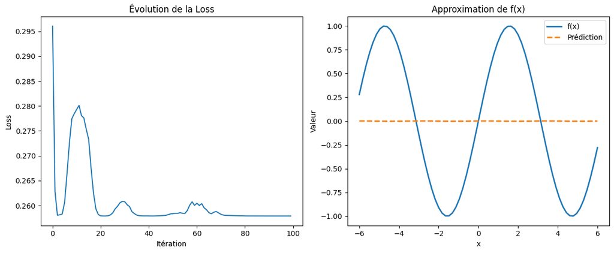

```python
# Hyper-paramètres

gamma = 1

steps = 100

# Retour des poids et courbe suite à l'entraînement

cst , weights = quantum_variational_fourier_encoding(fonction,gamma, steps)

# Affichage de la courbe

show_loss_approximate_fourrier(fonction,cst,weights, gamma)
```

Comme dans l'article, on remarque que le modèle avec un (\gamma) fixé au double de sa valeur précédente empêche catégoriquement la convergence du modèle pour l'approximation d'une fonction classique. Alors qu'avant cela n'aurait posé aucun problème. Cela montre la sensibilité au hyperparamètre de ce modèle de deep learning d'un nouveau genre.

### La fonction composée de divers membres sinus

Étant assez similaire à la fonction représentée sur le graphique, nous baserons notre rendu sur une approximation de cette dernière.

Résultat dans l'article :

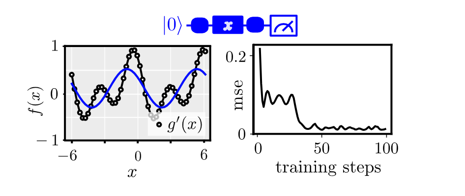

```
Step 10: Loss = 0.681509
Step 20: Loss = 0.668069
Step 30: Loss = 0.343118
Step 40: Loss = 0.209468
Step 50: Loss = 0.366385
Step 60: Loss = 0.226273
Step 70: Loss = 0.179623
Step 80: Loss = 0.217019
Step 90: Loss = 0.209078
Step 100: Loss = 0.298394
Temps d'exécution (torch=True) : 0.87065 secondes
```

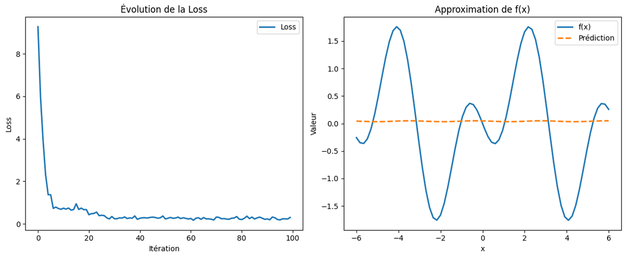

```
Cost at step  10: 0.263842
Cost at step  20: 0.267227
Cost at step  30: 0.286746
Cost at step  40: 0.262777
Cost at step  50: 0.258185
Cost at step  60: 0.258379
Temps d'exécution (torch=False) : 0.65362 secondes
```

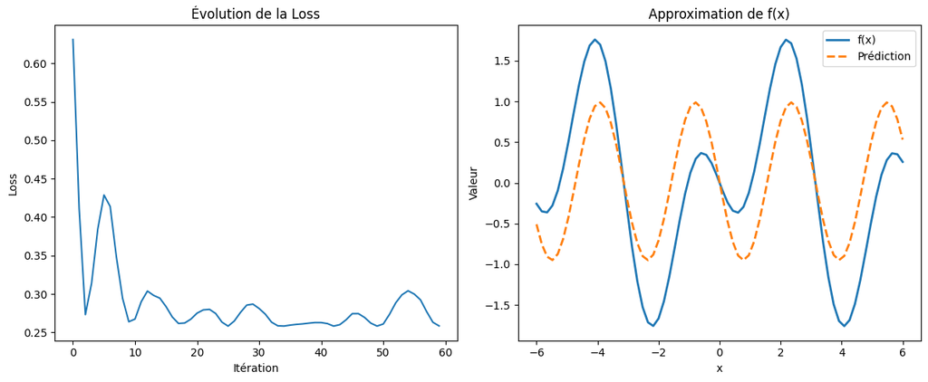

```python
# Hyper-paramètres

gamma = 2

steps = 100

# Fonction objectif à approximer
def fonction(x):
    return np.sin(x) - np.sin(2*x)

# Chronométrage des différents types d'exécution

start_time = time.time()
cst, weights = quantum_spectral_approximation(fonction, gamma, steps, torch=True)
end_time = time.time()
print(f"Temps d'exécution (torch=True) : {end_time - start_time:.5f} secondes")

show_loss_approximate_spectral(fonction, cst, weights, gamma, torch= True)

steps = 60

start_time = time.time()
cst, weights = quantum_spectral_approximation(fonction, gamma, steps)
end_time = time.time()
print(f"Temps d'exécution (torch=False) : {end_time - start_time:.5f} secondes")

# Affichage de la courbe
show_loss_approximate_spectral(fonction, cst, weights, gamma)
```

On procède à l'entraînement, comme dans son document de référence, avec $\gamma = 0.5$ sur le modèle sur base de Fourier.

```
Cost at step  10: 0.279131
Cost at step  20: 0.282954
Cost at step  30: 0.289430
Cost at step  40: 0.258643
Cost at step  50: 0.307664
Cost at step  60: 0.262932
Cost at step  70: 0.258264
Cost at step  80: 0.258199
Cost at step  90: 0.266264
Cost at step 100: 0.261372
```

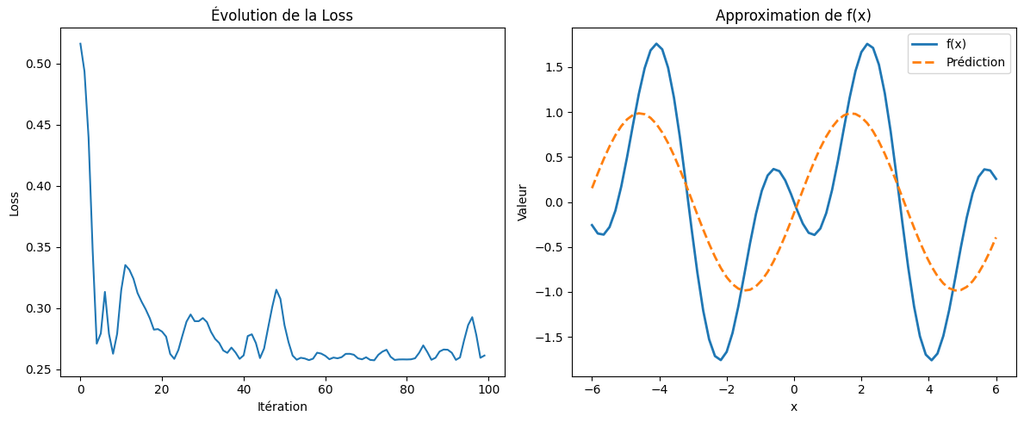

```python
# Hyper-paramètres

gamma = 0.5

steps = 100

# Retour des poids et courbe suite à l'entraînement

cst , weights = quantum_variational_fourier_encoding(fonction,gamma, steps)

# Affichage de la courbe

show_loss_approximate_fourrier(fonction,cst,weights, gamma)
```

Comme on l'avait présagé, la composition de fonctions élémentaires sinus et cosinus ne peut pas être approximée avec cette structure de deep learning quantique. Mais dans la section nous allons développer de nouvelles notions de manière à pallier ce problème.